# home_assignment

### Казачкова Анна, Никонова Евгения - БЭК 181

Задания 6-10 выполнены в R.

#### № 6

Была скачана объединенная база данных для домохозяйств RLMS в формате .dta, ее открыли в STATA-16 и выгрузили в виде .xlsx следующие переменные:

- ID_W - год проведения исследования
- ID_H - идентификационная переменная
- nfm - количество членов семьи
- C5 - cколько квадратных метров составляет площадь только жилых комнат у семьи
- E1_36B - cколько килограмм сыра, брынзы семья купила в течение последних 7 дней

В Excel - файле была произведена следующая замена для переменных C5, E1_36B: вместо *“Затрудняюсь ответить”*, *“Нет ответа”*, *“Отказ от ответа”* было проставлены нули.

Затем датасет был выгружен в формате .csv и назван *“data_ha.csv”*.

```r
setwd("D:/ha")
data_ha <- read.table("Data_ha.csv", sep = ";", dec = ",", header = TRUE)
head(data_ha)
```

```
##   ID_W ID_H nfm C5 E1_36B
## 1 1994 1001   2 17    0.2
## 2 1994 1002   4 44    1.0
## 3 1994 1003   1 17     NA
## 4 1994 1004   1 55     NA
## 5 1994 1005   2 29    0.5
## 6 1994 1006   3 17     NA
```

#### № 7

Самый главный вопрос: **“Поможет ли величина потребления сыра одного члена семьи предсказать размер жилой площади на одного человека?”**

#### № 8

Подготавливаем данные: 1. Для удобства переименнуем переменные

```r
names(data_ha)[1] <- "year"
names(data_ha)[2] <- "id"
names(data_ha)[3] <- "n_mem"
names(data_ha)[4] <- "liv_area"
names(data_ha)[5] <- "kg_cheese"
```

Смотрим, правильный ли тип данных определелился:

```r
str(data_ha)
```

```
## 'data.frame':    138371 obs. of  5 variables:
##  $ year     : int  1994 1994 1994 1994 1994 1994 1994 1994 1994 1994 ...
##  $ id       : int  1001 1002 1003 1004 1005 1006 1007 1008 1009 1012 ...
##  $ n_mem    : int  2 4 1 1 2 3 2 2 4 4 ...
##  $ liv_area : num  17 44 17 55 29 17 34 17 47 27 ...
##  $ kg_cheese: num  0.2 1 NA NA 0.5 NA NA NA 0.3 NA ...
```

R корректно определил формат данных.

2. Удалим из датасета все наблюдения, в которых нет данных по площади жилого помещения и потребления сыра

```r
data_ha <- data_ha[data_ha[4] > 0, ]
data_ha <- data_ha[data_ha[5] > 0, ]
```

3. Удалим все строки с пропущенными значениями, так как нас интересует выборка, где есть данные и по жилой площади, и по потреблению сыра

```r
data_ha <- na.omit(data_ha)
```

Посмотрим, сколько наблюдений осталось:

```r
str(data_ha)
```

```
## 'data.frame':    53764 obs. of  5 variables:
##  $ year     : int  1994 1994 1994 1994 1994 1994 1994 1994 1994 1994 ...
##  $ id       : int  1001 1002 1005 1009 1018 1022 1024 1028 1030 2004 ...
##  $ n_mem    : int  2 4 2 4 3 2 2 2 5 3 ...
##  $ liv_area : num  17 44 29 47 26 34 45 17.8 42.6 32.5 ...
##  $ kg_cheese: num  0.2 1 0.5 0.3 0.2 0.3 0.4 0.5 0.2 0.2 ...
##  - attr(*, "na.action")= 'omit' Named int [1:77182] 3 4 6 7 8 10 11 12 13 14 ...
##   ..- attr(*, "names")= chr [1:77182] "NA" "NA.1" "NA.2" "NA.3" ...
```

На период с 1994 по 2019 год у нас осталось 53 764 наблюдения, этого количества достаточно для нашего исследования.

4. Вычислим для каждого наблюдения величины жилой площади и потребления сыра на 1 члена семьи

```r
data_ha$av_liv_area <- round(data_ha$liv_area / data_ha$n_mem, 2)
data_ha$av_kg_cheese <- round(data_ha$kg_cheese / data_ha$n_mem,2)
```

5. Теперь удалим уже ненужные столбцы с количеством человек в семье, жилой площадью и потреблением сыра на всю семью

```r
data_ha <- data_ha[,-c(3,4,5)]
```

```r
head(data_ha)
```

```
##    year   id av_liv_area av_kg_cheese
## 1  1994 1001        8.50         0.10
## 2  1994 1002       11.00         0.25
## 5  1994 1005       14.50         0.25
## 9  1994 1009       11.75         0.07
## 16 1994 1018        8.67         0.07
## 20 1994 1022       17.00         0.15
```

**Теперь датасет готов к дальнейшему исследованию!**

Для работы с панельными данными нам понадобится библиотека: *plm*

```r
#install.packages("plm")
library("plm")
```

Также пригодится *tidyverse* для построения графиков:

```r
#install.packages("tidyverse")
library("tidyverse")
```

Понадобится пакет *cowplot* для вывода графиков вместе.

```r
#install.packages("cowplot")
library("cowplot")
```

Преобразуем наш датасет в новый с помощью команды из библиотеки *plm*:

```r
h <- pdata.frame(data_ha,
                 index = c("id", "year"),
                 row.names = TRUE)

head(h)
```

```
##           year   id av_liv_area av_kg_cheese
## 1001-1994 1994 1001        8.50         0.10
## 1002-1994 1994 1002       11.00         0.25
## 1002-2009 2009 1002        9.50         0.25
## 1004-2009 2009 1004       14.95         0.15
## 1005-1994 1994 1005       14.50         0.25
## 1006-2009 2009 1006       14.90         0.10
```

Проверим, сбалансированна ли панель данных:

```r
h %>%
  is.pbalanced()
```

```
## [1] FALSE
```

False - значит, панель не сбалансированна - исследуемые домохозяйства меняются с течением времени. Тогда, например, нет смысла делать графики для каждого отдельного домохозяйства, так как не будет данных на все года.

Построим графики с распредлением наблюдений по годам (будут показаны точками значения в каждой семье) со средним значением за каждый год для жилой площади и потребления сыра на 1 человека в семье.

Сначала для размера жилой площади:

```r
mean_a <-
  h %>%
  group_by(year) %>%
  summarise(mean_area = mean(av_liv_area))

mean_a
```

```
## # A tibble: 24 x 2
##    year  mean_area
##    <fct>     <dbl>
##  1 1994       12.2
##  2 1995       12.2
##  3 1996       13.1
##  4 1998       12.8
##  5 2000       13.1
##  6 2001       13.7
##  7 2002       13.7
##  8 2003       14.0
##  9 2004       14.0
## 10 2005       14.1
## # ... with 14 more rows
```

Находим среднее значение показателя для каждого года.

Строим график, где среднее значение будет выделено синей линией.

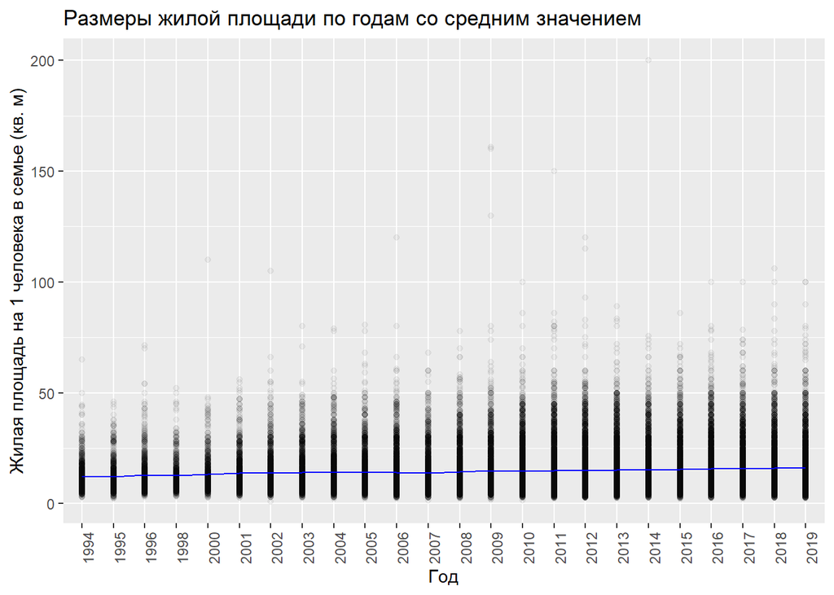

```r
ggplot(data = h,
       aes(x = year, y = av_liv_area)) +
  geom_point(alpha=0.05) +
  geom_line(data = mean_a, aes(x = year, y = mean_area), group = 1,col = "blue") +
  labs(x = "Год", y = "Жилая площадь на 1 человека в семье (кв. м)") +
  theme(axis.text.x = element_text(angle = 90)) +
  ggtitle ("Размеры жилой площади по годам со средним значением")
```

Аналогично делаем график для потребления сыра:

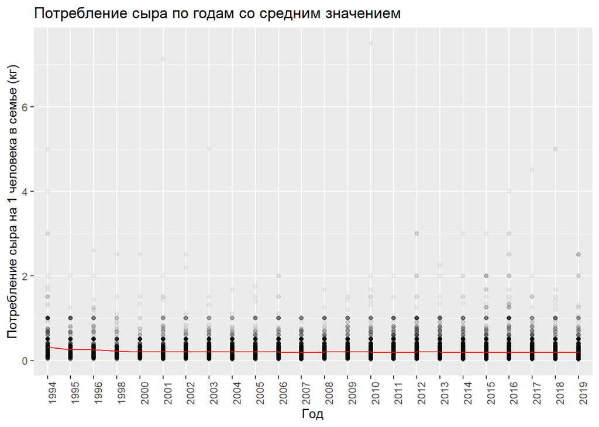

```r
mean_c <-
  h %>%
  group_by(year) %>%
  summarise(mean_cheese = mean(av_kg_cheese))

ggplot(data = h,
         aes(x = year, y = av_kg_cheese)) +
  geom_point(alpha=0.05) +
  geom_line(data = mean_c,aes(x = year, y = mean_cheese), group = 1,col = "red") +
  labs(x = "Год", y = "Потребление сыра на 1 человека в семье (кг)") +
  theme(axis.text.x = element_text(angle = 90)) +
  ggtitle ("Потребление сыра по годам со средним значением")
```

К сожалению, данные графики неудобны для визуального исследования. По ним невозможно сделать выводы на данном этапе.

Попытка перейти к логарифмам не меняет сильно ситуацию, среднее значение остается практически стабильным для обоих показателей.

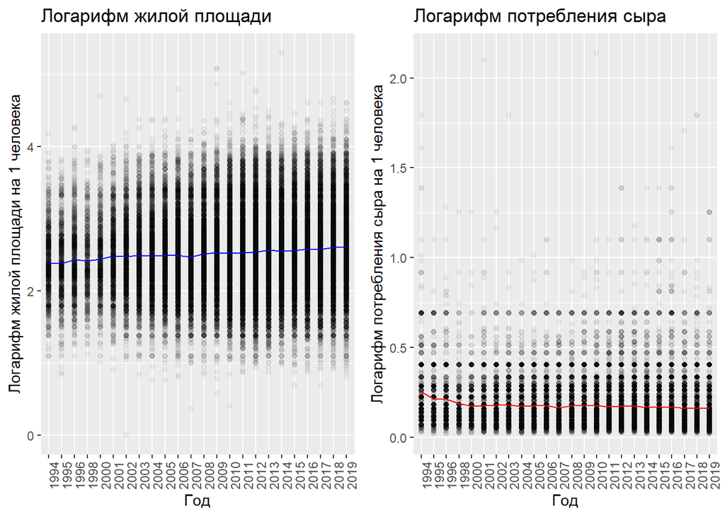

```r
mean_a_log <-
  h %>%
  group_by(year) %>%
  summarise(mean_area = mean(log(av_liv_area)))

p1 <- ggplot(data = h,
       aes(x = year, y = log(av_liv_area))) +
  geom_point(alpha=0.05) +
  geom_line(data = mean_a_log,aes(x = year, y = mean_area), group = 1,col = "blue") +
  labs(x = "Год", y = "Логарифм жилой площади на 1 человека") +
  theme(axis.text.x = element_text(angle = 90)) +
  ggtitle ("Логарифм жилой площади")

mean_c_log <-
  h %>%
  group_by(year) %>%
  summarise(mean_cheese = mean(log(1+av_kg_cheese)))

p2 <- ggplot(data = h,
         aes(x = year, y = log(1+av_kg_cheese))) +
  geom_point(alpha=0.05) +
  geom_line(data = mean_c_log,aes(x = year, y = mean_cheese), group = 1,col = "red") +
  labs(x = "Год", y = "Логарифм потребления сыра на 1 человека") +
  theme(axis.text.x = element_text(angle = 90)) +
  ggtitle ("Логарифм потребления сыра")

plot_grid(p1, p2,align = "h", nrow = 1, rel_widths = c(1, 1), rel_heights = c(1, 1))
```

Попробуем построить график с потреблением сыра и жилой площадью на осях, цветами будут обозначены различные года. Также на графике будет видна линейная регрессия.

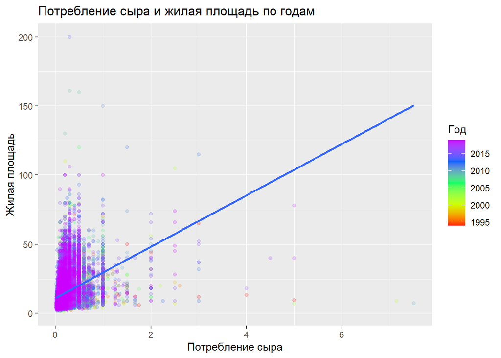

```r
ggplot(data = data_ha,
       aes(x = av_kg_cheese, y = av_liv_area, color = year))+
  geom_point(alpha=0.2) + labs(x = "Потребление сыра", y = "Жилая площадь")+ geom_smooth(method = "lm", se = F) + scale_color_gradientn(colours = rainbow(5)) + labs(color='Год') +
  ggtitle ("Потребление сыра и жилая площадь по годам")
```

Переход к логарифмам не меняет существенно ситуацию. Значения последних лет накладываются на предыдущие и всё перекрывают.

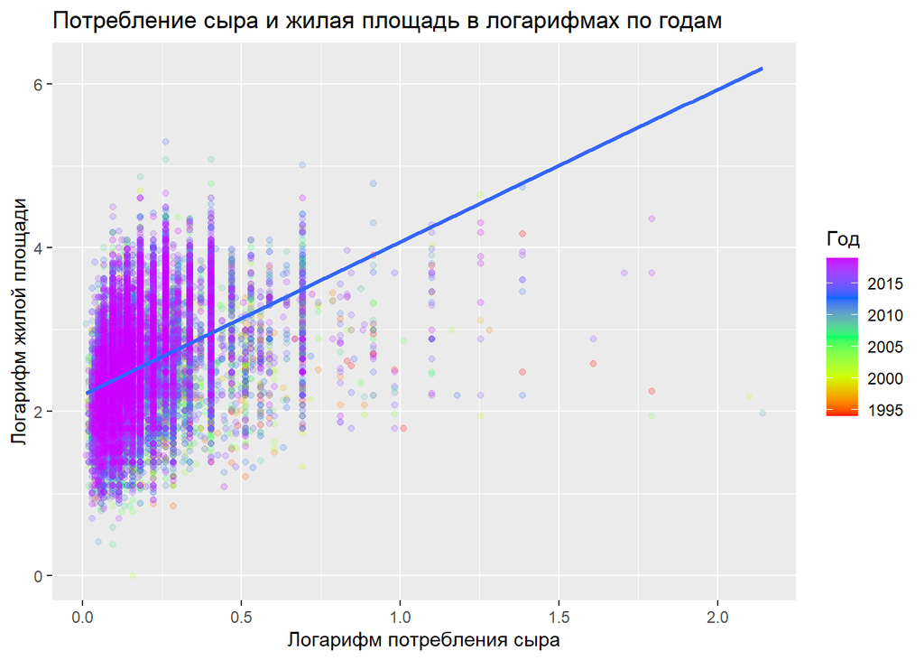

```r
ggplot(data = data_ha,
       aes(x = log(1+av_kg_cheese), y = log(av_liv_area), color = year))+
  geom_point(alpha=0.2) + geom_smooth(method = "lm", se = F) + labs(x = "Логарифм потребления сыра", y = "Логарифм жилой площади")+ labs(color='Год')+ scale_color_gradientn(colours = rainbow(5)) +
  ggtitle ("Потребление сыра и жилая площадь в логарифмах по годам")
```

Также посмотрим отдельные показатели по годам:

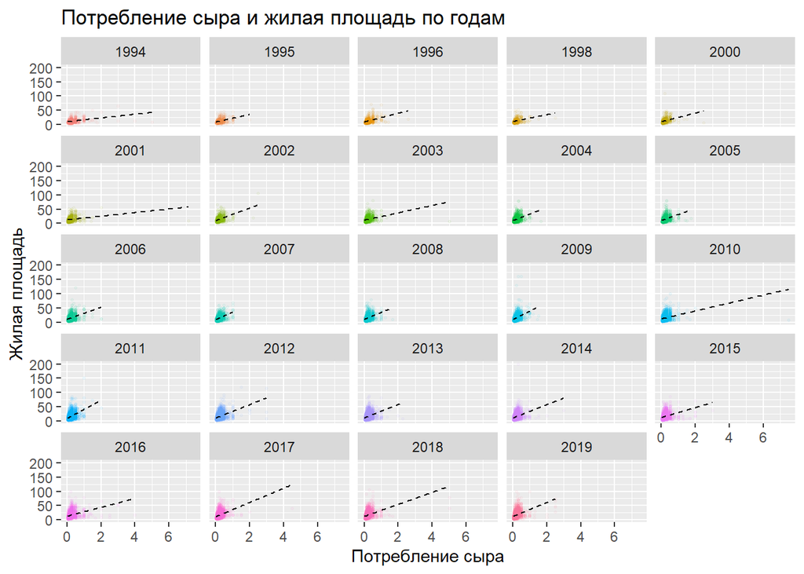

```r
ggplot(data = data_ha,
       aes(x =av_kg_cheese, y = av_liv_area ,color=as.factor(year) ))+
  geom_point(alpha=0.05, size = 0.5) + geom_smooth(method = "lm", se = F, lty = "dashed", color = 'black',size = 0.5) +  facet_wrap(~year) + labs(x = "Потребление сыра", y = "Жилая площадь") + ggtitle ("Потребление сыра и жилая площадь по годам") + theme(legend.position="none")
```

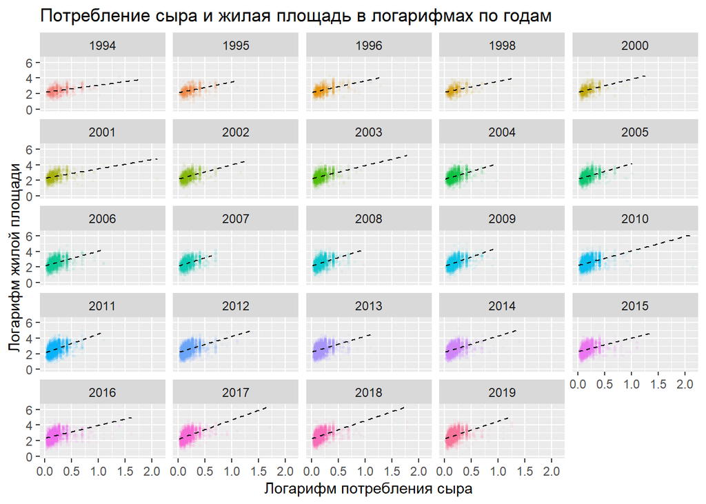

```r
ggplot(data = data_ha,
       aes(x = log(1+av_kg_cheese), y = log(av_liv_area),color=as.factor(year) ))+
  geom_point(alpha=0.05, size = 0.5) + geom_smooth(method = "lm", se = F, lty = "dashed", color = 'black', size = 0.5) + facet_wrap(~year) + labs(x = "Логарифм потребления сыра", y = "Логарифм жилой площади") +
  ggtitle ("Потребление сыра и жилая площадь в логарифмах по годам")+ theme(legend.position="none")
```

Отметим, что со временем потребление сыра и жилая площадь почти не меняются. Поэтому сложно сказать, связаны ли эти параметры и можно ли с помощью одного предсказать второй.

#### № 9

Составим 3 модели: сквозную (pooled), с рандомными (re) и фиксированными эффектами (fe).

```r
h.pooled <- plm(av_liv_area ~ av_kg_cheese, data = h, model = "pooling")
h.re <- plm(av_liv_area ~ av_kg_cheese, data = h, model = "random")
h.fe <- plm(av_liv_area ~ av_kg_cheese, data = h, model = "within")
```

Выведем результаты для них:

```r
summary(h.pooled)
```

```
## Pooling Model
##
## Call:
## plm(formula = av_liv_area ~ av_kg_cheese, data = h, model = "pooling")
##
## Unbalanced Panel: n = 20479, T = 1-16, N = 53764
##
## Residuals:
##      Min.   1st Qu.    Median   3rd Qu.      Max.
## -143.2283   -5.4043   -2.0897    2.7507  183.3216
##
## Coefficients:
##               Estimate Std. Error t-value  Pr(>|t|)
## (Intercept)  11.103453   0.058588 189.517 < 2.2e-16 ***
## av_kg_cheese 18.583315   0.221708  83.819 < 2.2e-16 ***
## ---
## Signif. codes:  0 '***' 0.001 '**' 0.01 '*' 0.05 '.' 0.1 ' ' 1
##
## Total Sum of Squares:    4877000
## Residual Sum of Squares: 4313400
## R-Squared:      0.11558
## Adj. R-Squared: 0.11556
## F-statistic: 7025.58 on 1 and 53762 DF, p-value: < 2.22e-16
```

```r
summary(h.re)
```

```
## Oneway (individual) effect Random Effect Model
##    (Swamy-Arora's transformation)
##
## Call:
## plm(formula = av_liv_area ~ av_kg_cheese, data = h, model = "random")
##
## Unbalanced Panel: n = 20479, T = 1-16, N = 53764
##
## Effects:
##                  var std.dev share
## idiosyncratic 25.490   5.049 0.326
## individual    52.779   7.265 0.674
## theta:
##    Min. 1st Qu.  Median    Mean 3rd Qu.    Max.
##  0.4293  0.5590  0.6718  0.6384  0.7271  0.8288
##
## Residuals:
##    Min. 1st Qu.  Median    Mean 3rd Qu.    Max.
## -78.677  -2.758  -0.946   0.019   1.616 144.495
##
## Coefficients:
##               Estimate Std. Error z-value  Pr(>|z|)
## (Intercept)  12.424258   0.069313 179.248 < 2.2e-16 ***
## av_kg_cheese 11.354222   0.182357  62.264 < 2.2e-16 ***
## ---
## Signif. codes:  0 '***' 0.001 '**' 0.01 '*' 0.05 '.' 0.1 ' ' 1
##
## Total Sum of Squares:    1676500
## Residual Sum of Squares: 1423100
## R-Squared:      0.15125
## Adj. R-Squared: 0.15124
## Chisq: 3876.78 on 1 DF, p-value: < 2.22e-16
```

```r
summary(h.fe)
```

```
## Oneway (individual) effect Within Model
##
## Call:
## plm(formula = av_liv_area ~ av_kg_cheese, data = h, model = "within")
##
## Unbalanced Panel: n = 20479, T = 1-16, N = 53764
##
## Residuals:
##      Min.   1st Qu.    Median   3rd Qu.      Max.
## -60.53043  -0.93587   0.00000   0.71429 121.06087
##
## Coefficients:
##              Estimate Std. Error t-value  Pr(>|t|)
## av_kg_cheese  8.17396    0.20425  40.018 < 2.2e-16 ***
## ---
## Signif. codes:  0 '***' 0.001 '**' 0.01 '*' 0.05 '.' 0.1 ' ' 1
##
## Total Sum of Squares:    889250
## Residual Sum of Squares: 848420
## R-Squared:      0.045907
## Adj. R-Squared: -0.54113
## F-statistic: 1601.48 on 1 and 33284 DF, p-value: < 2.22e-16
```

Коэффициенты в 3 моделях различаются, везде являются значимыми.

Сравним эти модели:

1. F-тест - FE против сквозной регрессии

```r
pFtest(h.fe, h.pooled)
```

```
##
##  F test for individual effects
##
## data:  av_liv_area ~ av_kg_cheese
## F = 6.6379, df1 = 20478, df2 = 33284, p-value < 2.2e-16
## alternative hypothesis: significant effects
```

Нулевая гипотеза в этом тесте - сквозная модель верна. H0 отвергается в пользу альтернативной гипотезы о верности модели FE.

2. Тест Хаусмана - FE против RE

```r
phtest(h.fe, h.re)
```

```
##
##  Hausman Test
##
## data:  av_liv_area ~ av_kg_cheese
## chisq = 1194.7, df = 1, p-value < 2.2e-16
## alternative hypothesis: one model is inconsistent
```

Значение p-value очень мало, нулевая гипотеза отвергается на любом адекватном уровне значимости, то есть в RE оценки несостоятельны.

3. Тест Бройша-Пагана - RE против сквозной регрессии.

```r
plmtest(h.re, type = "bp")
```

```
##
##  Lagrange Multiplier Test - (Breusch-Pagan) for unbalanced panels
##
## data:  av_liv_area ~ av_kg_cheese
## chisq = 36157, df = 1, p-value < 2.2e-16
## alternative hypothesis: significant effects
```

Здесь не отвергается альтернативная гипотеза, то есть c_i не равны 0 в сквозной регрессии (регрессия не верна).

**Вывод:**

Согласно трем проведенным тестам FE - наилучшая модель. Коэффициент при av_kg_cheese значим и равнятся 8,17. Однако, R^2 у регрессии очень мал (меньше 5%), что означает плохую предсказывающую способность регрессии и возможную нехватку предикторов в модели.

#### № 10

**Ответ на самый главный вопрос:**

Согласно проведенной выше работе, потребление сыра на 1 члена в семье не помогает предсказать размер жилой площади на одного человека в семье.